# Machine Learning HW #3

David Coit

```r
library(caret)
library(ROCR)
library(pROC)
```

```r
library(MASS)
library(ggplot2)
library(gridExtra)
library(dplyr)
library(ggfortify)
library(glmnet)
library(tidyverse)
library(LogicReg)
library(mlbench)
library(LiblineaR)
library(party)
```

# Homework

## Lasso

2. Create and train model

```r
train_size <- floor(0.75 * nrow(airquality))
set.seed(543)
train_pos <- sample(seq_len(nrow(airquality)), size = train_size)
train_regression <- airquality[train_pos,-c(1,2)]
test_regression <- airquality[-train_pos,-c(1,2)]

ctrl = trainControl

lasso_regression <- train(Temp ~ .,
                          data = train_regression,
                          method = 'lasso')
```

Examine the residuals

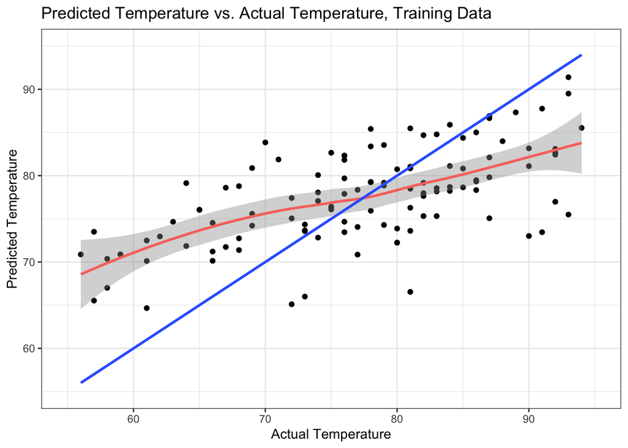

```r
# plot the predicted values vs the observed values
# for the training set
ggplot(data = train_regression) +
  # Plot scatter of predicted vs. true temperatures
  geom_point(aes(x=Temp, y=predict(lasso_regression, newdata = train_regression))) +
  # Plot smooth trend line of predicted v. true temp
  geom_smooth(aes(x=Temp, y=predict(lasso_regression, newdata = train_regression), color = 'r')) +
  # Plot identity function as reference
  geom_smooth(aes(x=Temp, y=Temp)) +
  theme_bw() +
  xlim(55,95) +
  ylim(55,95) +
  xlab("Actual Temperature") +
  ylab("Predicted Temperature") +
  ggtitle("Predicted Temperature vs. Actual Temperature, Training Data") +
  theme(legend.position = 'none')
```

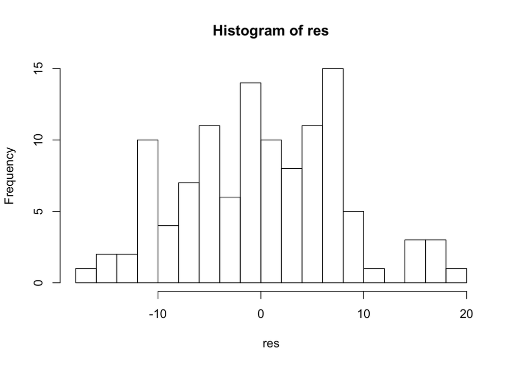

```r
# training data residuals
res <- residuals(lasso_regression)
hist(res, breaks = 20)
```

```r
summary(res)
```

```
##     Min.  1st Qu.   Median     Mean  3rd Qu.     Max.
## -16.5015  -5.3436   0.0251   0.0000   5.6568  18.4475
```

```r
shapiro.test(res)
```

```
##
##  Shapiro-Wilk normality test
##
## data:  res
## W = 0.98576, p-value = 0.272
```

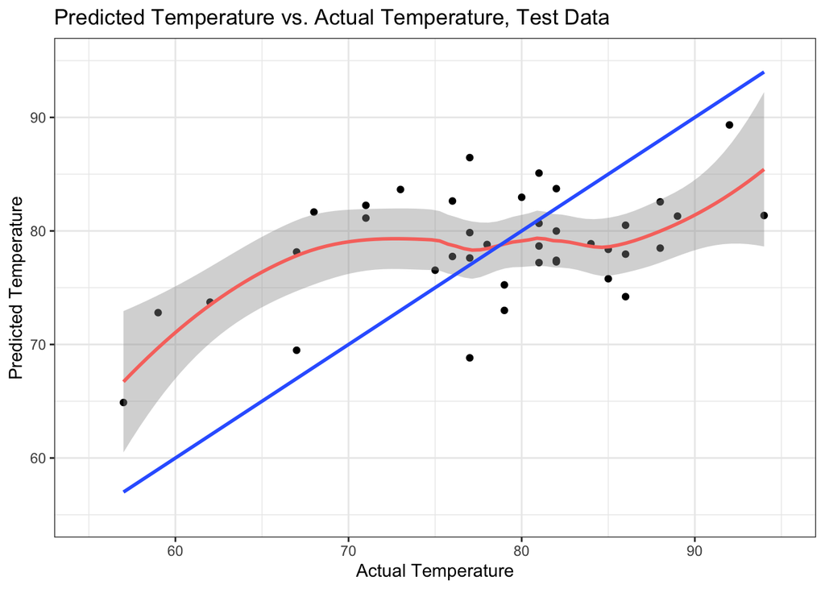

```r
# plot the predicted values vs the observed values
# for the testing set
ggplot(data = test_regression) +
  # Plot scatter of predicted vs. true temperatures
  geom_point(aes(x=Temp, y=predict(lasso_regression, newdata = test_regression))) +
  # Plot smooth trend line of predicted v. true temp
  geom_smooth(aes(x=Temp, y=predict(lasso_regression, newdata = test_regression), color = 'r')) +
  # Plot identity function as reference
  geom_smooth(aes(x=Temp, y=Temp)) +
  theme_bw() +
  xlim(55,95) +
  ylim(55,95) +
  xlab("Actual Temperature") +
  ylab("Predicted Temperature") +
  ggtitle("Predicted Temperature vs. Actual Temperature, Test Data") +
  theme(legend.position = 'none')
```

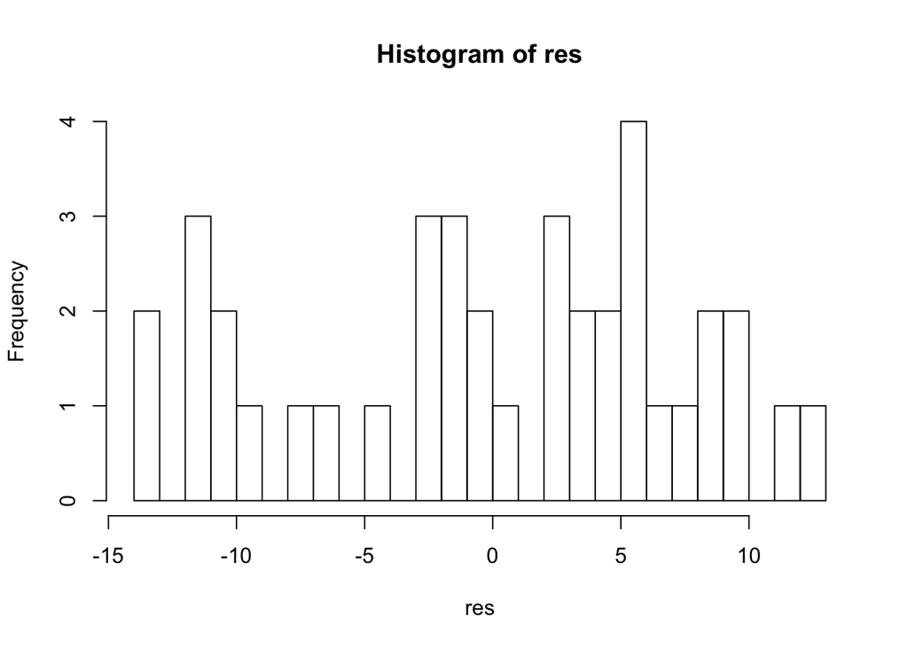

```r
# testing data residuals
test_observed = test_regression$Temp
test_predicted = predict(lasso_regression, newdata = test_regression)
res = test_observed - test_predicted
hist(res, breaks = 20)
```

```r
summary(res)
```

```
##     Min.  1st Qu.   Median     Mean  3rd Qu.     Max.
## -13.8027  -5.3647   0.3339  -0.1353   5.4665  12.6410
```

```r
shapiro.test(res)
```

```
##
##  Shapiro-Wilk normality test
##
## data:  res
## W = 0.95149, p-value = 0.09227
```

**When using the training data, the lasso regression mean residual value is 0, with a small median value of as well. The residuals also appear to follow a normal distribution. The test data also has a mean and median close to zero. While the residuals don’t appear to be normally distributed at first glance, a Shapiro-Wilk normality test p-value of ~0.09 is not indicative of significant probability non-normality.**

1. Use the Breast Cancer dataset from the mlbench package, and predict whether the cancer is malignant or benign using one of the algorithms we learned about in class. Give some rationale as to why you chose this algorithm. Plot ROC curves, and confusion matrices. If you are choosing a hyperparameter like K or lambda, explain how and why you chose it.

```r
# Import and format data
data(BreastCancer)
# Drop ID column
BreastCancer = subset(BreastCancer, select = -c(1))
# Set "Class" as a factor, other columns as numerical values
BreastCancer[["Class"]] = factor(BreastCancer[["Class"]])
cols = c(1,2,3,4,5,6,7,8,9);
BreastCancer[,cols] = apply(BreastCancer[,cols], 2, function(x) as.numeric(as.character(x)))
# Drop any rows containg NA values
BreastCancer = na.omit(BreastCancer)
# Set random seed
set.seed(314)

# test data split
train_size <- floor(0.75 * nrow(BreastCancer))
train_index <- sample(seq_len(nrow(BreastCancer)),
                      size = train_size)
train_data <- BreastCancer[train_index,]
test_data <- BreastCancer[-train_index,]

# model train control parameters
ctrl <- trainControl(method = "LOOCV",
                     classProbs = T,
                     savePredictions = T)

#train model
bayesGLM <- train(Class ~ .,
             method = 'bayesglm',
             data = train_data,
             trControl = ctrl,
             family = "binomial",
             na.action = na.pass)

bayesGLM
```

```
## Bayesian Generalized Linear Model
##
## 512 samples
##   9 predictor
##   2 classes: 'benign', 'malignant'
##
## No pre-processing
## Resampling: Leave-One-Out Cross-Validation
## Summary of sample sizes: 511, 511, 511, 511, 511, 511, ...
## Resampling results:
##
##   Accuracy   Kappa
##   0.9707031  0.9351527
```

**I chose the Bayes GLM regression in part because I have never worked with Bayesian models before, and I wanted to use this assignment as a way to experiment with one. I admit that although the Bayes model allows us to supply values for the prior assumptions about the data, I am not sure how this applies with a logistic regression. Finally, in my experimentation, this model had high accuracy and ran quickly on my machine (compared to random forest with LOOCV eg.)**

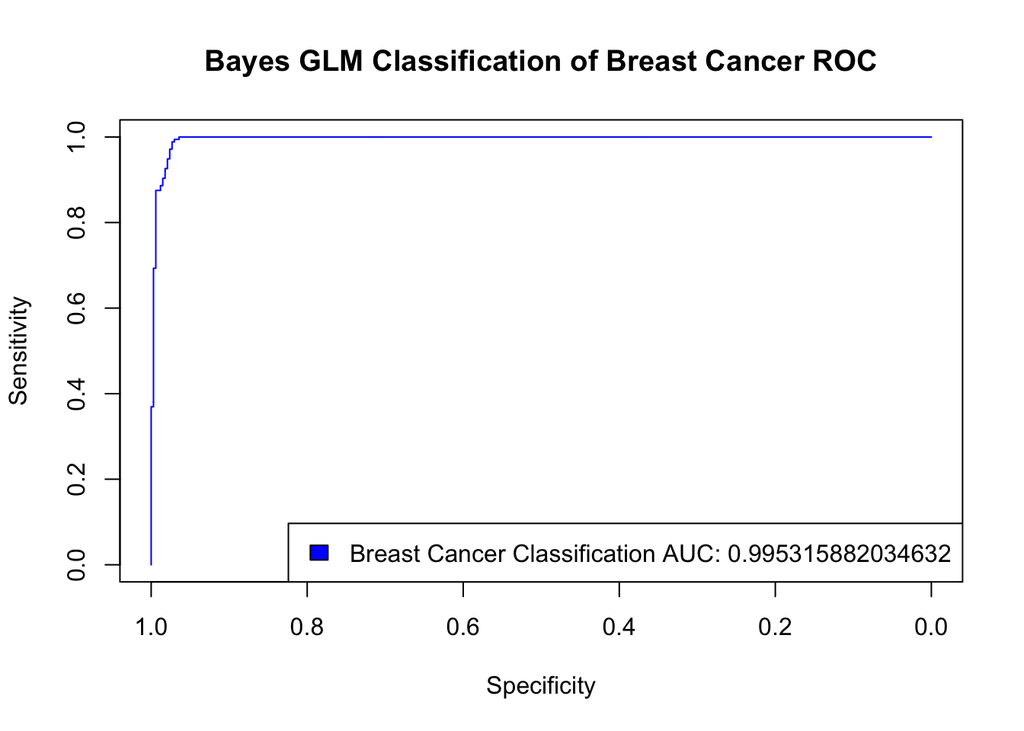

```r
#ROC curve
plot(x = roc(predictor = bayesGLM$pred$malignant,
             response = bayesGLM$pred$obs)$specificities,
     y = roc(predictor = bayesGLM$pred$malignant,
             response = bayesGLM$pred$obs)$sensitivities,
     col= "blue", xlim = c(1, 0), type ="l", ylab = "Sensitivity",
     xlab = "Specificity")
legend("bottomright",
       legend = paste("Breast Cancer Classification AUC: ",
                                     roc(predictor = bayesGLM$pred$malignant,
                                         response = bayesGLM$pred$obs)$auc, sep = ""),
       col = c("blue"),
       fill = c("blue"))
title("Bayes GLM Classification of Breast Cancer ROC")
```

```r
# Confusion matrix

bayesGLM_predict <- predict(bayesGLM,
                            newdata = test_data)

cm <- confusionMatrix(bayesGLM_predict,
                reference = test_data$Class)
cm
```

```
## Confusion Matrix and Statistics
##
##            Reference
## Prediction  benign malignant
##   benign       106         6
##   malignant      2        57
##
##                Accuracy : 0.9532
##                  95% CI : (0.9099, 0.9796)
##     No Information Rate : 0.6316
##     P-Value [Acc > NIR] : <2e-16
##
##                   Kappa : 0.8981
##
##  Mcnemar's Test P-Value : 0.2888
##
##             Sensitivity : 0.9815
##             Specificity : 0.9048
##          Pos Pred Value : 0.9464
##          Neg Pred Value : 0.9661
##              Prevalence : 0.6316
##          Detection Rate : 0.6199
##    Detection Prevalence : 0.6550
##       Balanced Accuracy : 0.9431
##
##        'Positive' Class : benign
##
```

```r
cm$byClass["F1"]
```

```
##        F1
## 0.9636364
```

**Both the accuracy and the F1 score for this model are high, with values of 0.95 and 0.96 respectively.**